# Week 9 - Final Model

Kyle Riebeling

2025-12-05

## Simplifying our model

Income and share provide reciprocal information, so we do not need to include both of them. We will remove income, since share has a higher correlation. A partial F-test would state that we should keep income, but that is because the reciprocal information is causing the linear regression to produce invalid results. Removing income should make our residuals act more normal and produce a model that is more accurate to the true regression line, even if it reduces our adjusted $R^2$ and RMSE.

```r
model1 <- lm(expenditure ~ sqrt(share) * dependents + months + active, data = train_data)
summary(model1)
```

```
Call:
lm(formula = expenditure ~ sqrt(share) * dependents + months +
    active, data = train_data)

Residuals:
    Min      1Q  Median      3Q     Max
-711.51  -89.24  -17.52   52.55 2304.20

Coefficients:
                          Estimate  Std. Error t value    Pr(>|t|)
(Intercept)            -223.910187   20.732030 -10.800     < 2e-16 ***
sqrt(share)            1553.687725   57.053709  27.232     < 2e-16 ***
dependents              -21.780578   11.313619  -1.925     0.05462 .
months                   -0.003511    0.104579  -0.034     0.97323
active                    3.944426    1.154372   3.417     0.00067 ***
sqrt(share):dependents  203.621885   38.655980   5.268 0.000000185 ***
---
Signif. codes:  0 '***' 0.001 '**' 0.01 '*' 0.05 '.' 0.1 ' ' 1

Residual standard error: 177.1 on 695 degrees of freedom
Multiple R-squared:  0.6651,    Adjusted R-squared:  0.6626
F-statistic:   276 on 5 and 695 DF,  p-value: < 2.2e-16
```

```r
modelAnalysis(model1, test_data)
```

|  | model_values |
| --- | --- |
| Training R^2 | 0.6626438 |
| Test R^2 | 0.6693161 |
| RMSE | 141.0482510 |

Now we will see if months is important to keep in our model, since it is showing as insignificant in our model summary output.

```r
model2 <- lm(expenditure ~ sqrt(share) * dependents + active, data = train_data)
anova(model1, model2)
```

```
Analysis of Variance Table

Model 1: expenditure ~ sqrt(share) * dependents + months + active
Model 2: expenditure ~ sqrt(share) * dependents + active
  Res.Df      RSS Df Sum of Sq      F Pr(>F)
1    695 21800698
2    696 21800733 -1   -35.355 0.0011 0.9732
```

The parital F-test comparing the full model, model1, vs the reduced model, model2, reported a very high p-value of .9732. This means the difference in adding months as a predictor is not significant at all. We should exclude months and use the simpler model, model2.

```r
summary(model2)
```

```
Call:
lm(formula = expenditure ~ sqrt(share) * dependents + active,
    data = train_data)

Residuals:
    Min      1Q  Median      3Q     Max
-711.50  -89.16  -17.41   52.77 2304.03

Coefficients:
                       Estimate Std. Error t value    Pr(>|t|)
(Intercept)            -224.075     20.126 -11.134     < 2e-16 ***
sqrt(share)            1553.777     56.951  27.283     < 2e-16 ***
dependents              -21.791     11.301  -1.928     0.05423 .
active                    3.939      1.141   3.452     0.00059 ***
sqrt(share):dependents  203.613     38.627   5.271 0.000000181 ***
---
Signif. codes:  0 '***' 0.001 '**' 0.01 '*' 0.05 '.' 0.1 ' ' 1

Residual standard error: 177 on 696 degrees of freedom
Multiple R-squared:  0.6651,    Adjusted R-squared:  0.6631
F-statistic: 345.5 on 4 and 696 DF,  p-value: < 2.2e-16
```

```r
modelAnalysis(model2, test_data)
```

|  | model_values |
| --- | --- |
| Training R^2 | 0.6631279 |
| Test R^2 | 0.6693098 |
| RMSE | 141.0495765 |

We can see in the model summary output that our adjusted $R^2$ actually went up slightly by excluding months. This confirms that months was just adding random noise to our model.

## Residual and Assumption Review

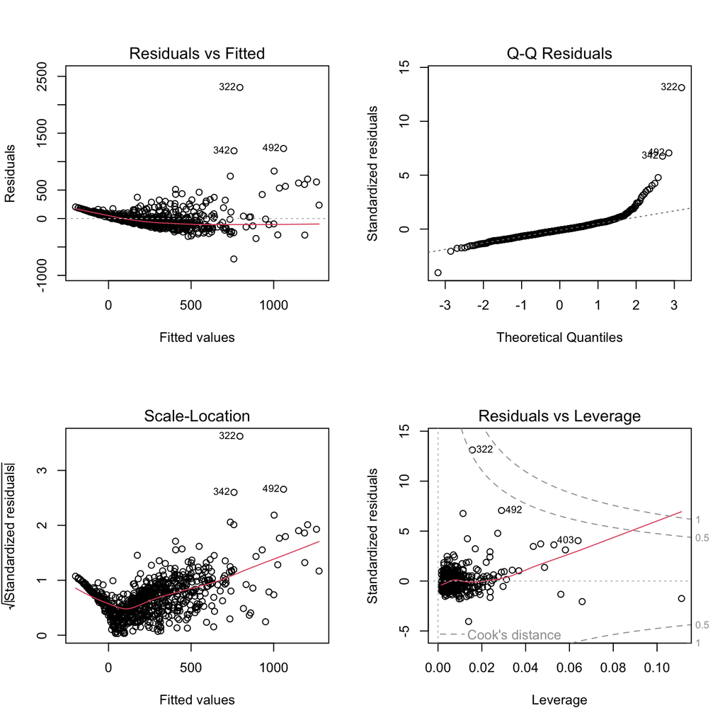

```
Shapiro-Wilk's normality test for our model:

    Shapiro-Wilk normality test

data:  residuals(model)
W = 0.70787, p-value < 2.2e-16


Durbin-Watson's independence test for our model:

 lag Autocorrelation D-W Statistic p-value
   1      0.02061422      1.957867   0.504
 Alternative hypothesis: rho != 0
```

To remove outliers, we will look at standarized residuals and remove any that are over 3 standard deviations from 0. From our Q-Q plot, we can see 3 highlighted observations that are over 5 standard deviations from 0. We will start be removing these and checking our model again.

```r
train_data <- train_data[-c(342, 322, 492)
                         ,]
model3 <- lm(expenditure ~ sqrt(share) * dependents + active, data = train_data)
summary(model3)
```

```
Call:
lm(formula = expenditure ~ sqrt(share) * dependents + active,
    data = train_data)

Residuals:
   Min     1Q Median     3Q    Max
-662.0  -78.2  -15.4   52.5  869.5

Coefficients:
                        Estimate Std. Error t value   Pr(>|t|)
(Intercept)            -204.6722    15.7788 -12.971    < 2e-16 ***
sqrt(share)            1491.9818    44.6400  33.423    < 2e-16 ***
dependents              -10.0464     8.8742  -1.132    0.25799
active                    2.9297     0.8972   3.265    0.00115 **
sqrt(share):dependents  146.9072    30.4806   4.820 0.00000177 ***
---
Signif. codes:  0 '***' 0.001 '**' 0.01 '*' 0.05 '.' 0.1 ' ' 1

Residual standard error: 138.4 on 693 degrees of freedom
Multiple R-squared:  0.7338,    Adjusted R-squared:  0.7323
F-statistic: 477.7 on 4 and 693 DF,  p-value: < 2.2e-16
```

```r
modelAnalysis(model3, test_data)
```

|  | model_values |
| --- | --- |
| Training R^2 | 0.7322955 |
| Test R^2 | 0.6774364 |
| RMSE | 139.3056785 |

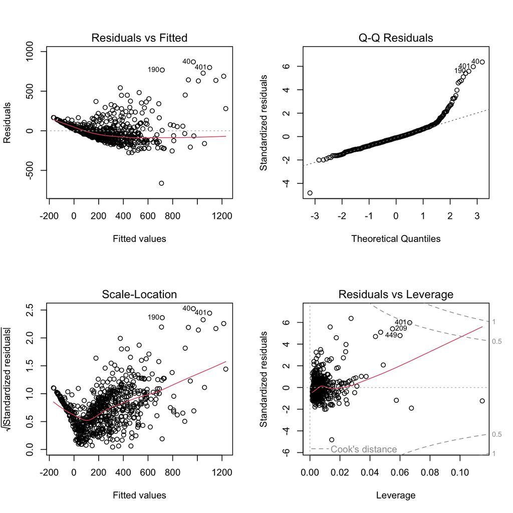

```
Shapiro-Wilk's normality test for our model:

    Shapiro-Wilk normality test

data:  residuals(model)
W = 0.84378, p-value < 2.2e-16


Durbin-Watson's independence test for our model:

 lag Autocorrelation D-W Statistic p-value
   1      0.03951034      1.920326     0.3
 Alternative hypothesis: rho != 0
```

## Prediction Accuracy

```r
modelAnalysis(model3, test_data)
```

|  | model_values |
| --- | --- |
| Training R^2 | 0.7322955 |
| Test R^2 | 0.6774364 |
| RMSE | 139.3056785 |

This model performs better on the training data, with a slightly lower adjusted $R^2$ on the testing data. The RMSE, however, is still relatively low, showing that it is not completely useless in predicting expenditure. A test adjusted $R^2$ of .6774 and a RMSE of 139.306 shows that this model generalizes moderately well, with only slight instability between training and testing.

## Model Reflection and Interpretation

My final model is as follows:

$E[expenditure] = -204.6722 + 1491.9818(\sqrt{share}) + -10.0464(dependents) + 2.9297(active) + 146.9072(\sqrt{share})(dependents)$

The intercept is not useful, as a negative value for expenditure is not possible. Across all $B_1 \rightarrow B_4$, it is easy to see that $\sqrt{share}$ is the most important predictor variable. $B_1$ is much higher than all other predictors. The next highest is $B_4$, which is the interaction between $\sqrt{share}$ and dependents. Active was found to also have a small significant effect. Dependents on its own was not significant.

The most important change to our model was dropping income since it added redundant information and made the least squares method “break”. Removing income made our residuals closer to normality and made our model and beta coefficients easier to interpret. When trying out different combinations of transformations, higher-order terms, and predictor variables, I obtained models that were slightly closer to passing residual analysis. None passed, however. Because none of my models passed residual analysis, I decided to used a much simpler model that was much more interpretable and still reasonably close to passing our residual analysis. Using the complex models would’ve left me with a model that did not satisfy the residual assumptions and would be useless practically, since the data was so transformed.